# Central Limit Theorem Simulations

##1. Normally Distributed Random Variables

First, let’s generate data from a normal distribution:

$$X_i \stackrel{i.i.d.}{\sim} N(\mu, \sigma^2)$$

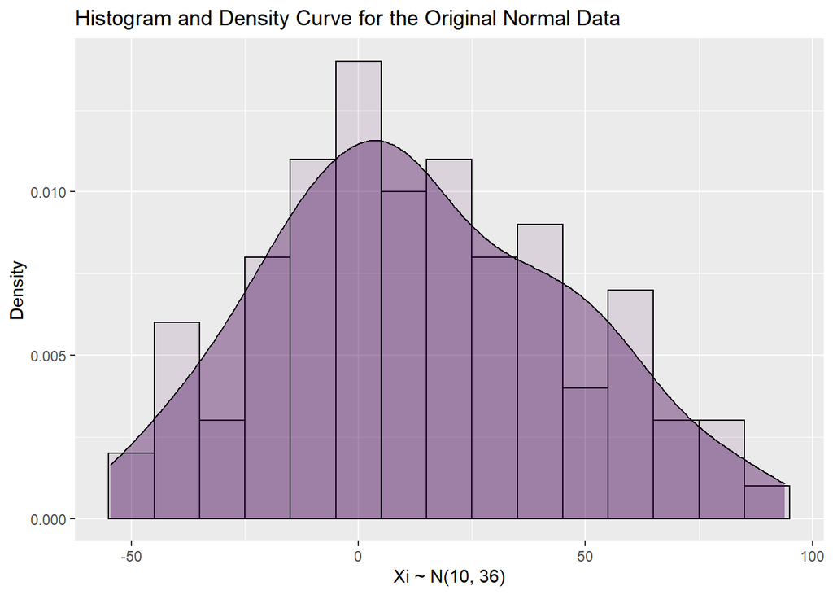

- What if we can only observe/sample 10 observations from this population?
- What if we repeatedly took samples of size 10 from the original population?
- How would the means of each smaller sample be distributed, compare to the whole sample?

Generate and plot the mean sampling distribution of 100 random samples of size 10 (with replacement) from the original Normal distribution

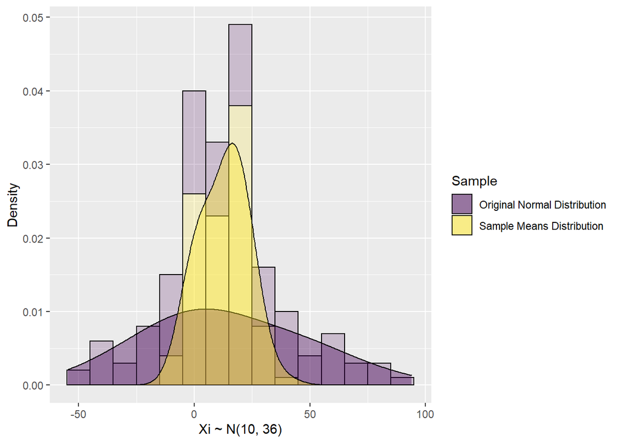

##2. Non-normally distributed random variables

## Poisson Distribution

Generate data from a Poisson distribution:

Generate and plot the mean sampling distribution of 100 random samples of size 10 (with replacement) from the original Poisson distribution:

[figure not shown]

Generate and plot the mean sampling distribution of 100 random samples of size 30 (with replacement) from the original Poisson distribution:

[figure not shown]

## Binomial Distribution

Generate data from a Binomial distribution:

$$X_i \stackrel{i.i.d.}{\sim} Bin(50,0.05)$$

Generate and plot the mean sampling distribution of 100 random samples of size 10 (with replacement) from the original Binomial distribution:

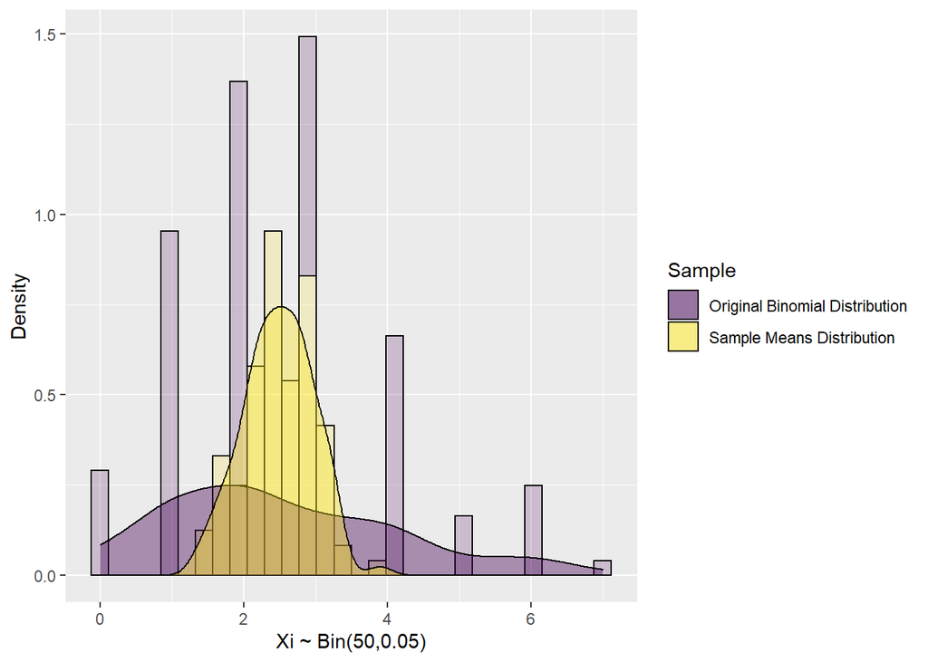

Generate and plot the mean sampling distribution of 100 random samples of size 30 (with replacement) from the original Binomial distribution:

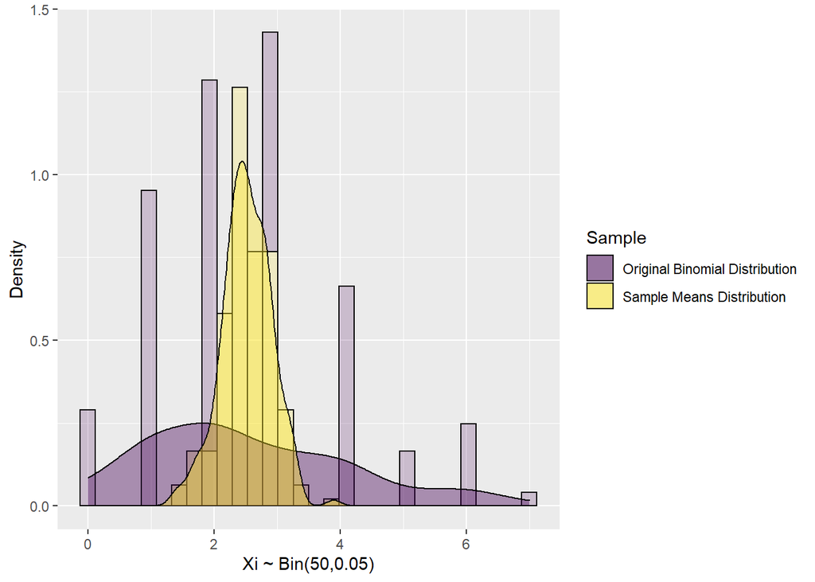